# Kernel Density Estimation using R

2025-11-17

## Density Estimation

Suppose a random sample \(X_1, \ldots, X_n\) is drawn from a population with an unknown continuous probability density function \(f(x)\).

Goal: estimate \(f(x)\).

### Histogram

Partition the range of data into subintervals \[ a_1 < a_2 < \cdots < a_k. \]

For \(x \in (a_i, a_{i+1}]\), \[ \hat f(x) = \frac{\#\{\text{observations} \in (a_i, a_{i+1}]\}}{n(a_{i+1} - a_i)}. \]

## Bandwidth

- Typically, the intervals have equal length \(h\): \((a_{i+1} - a_i) = 2h\) for \(i = 1, \ldots, k\). The equal interval length \(h\) is often referred to as the **bandwidth**.
- In this case, for any \(x\) within the data range, \[ \hat f(x) = \frac{\#\{\text{observations within } h \text{ of } x\}}{2nh} = \frac{1}{2nh} \sum_{i=1}^n I(|X_i - x| \le h). \]
- Narrow intervals (smaller \(h\)): histogram has a choppy appearance, large variance.
- Large intervals (larger \(h\)): histogram may lose local features, large bias.
- Generally, a larger sample size \(n\) requires a smaller \(h\), thus more intervals.

Suggested bandwidth: \[ h = \frac{1.75}{n^{1/3}} S, \] where \(S\) is the sample standard deviation.

## Histograms

- Histograms provide an idea about the data distribution.
- Look at the definition again:

\[ \hat{f}(x) = \frac{ \text{No. of observations within } h \text{ of } x }{n \times 2h} \\ \] or,

\[ \hat{f}(x) = \frac{1}{2nh} \sum_{i=1}^{n} I(|{X_i - x}| \le h). \]

- Narrow intervals (smaller h): histogram has a choppy appearance, large variance.
- Large intervals (larger h): histogram may lose the local feature, large bias.

## R `hist()`

- In base R’s `hist()` method, you can use the `break` argument:
- `breaks` can be one of:
1. a vector giving the breakpoints between histogram cells,
2. a function to compute the vector of breakpoints,
3. a single number giving the number of cells for the histogram,
4. a character string naming an algorithm to compute the number of cells (see ‘Details’),
5. a function to compute the number of cells.

## Sampling distribution

- By default, number of breaks is calculated by using Sturges’ formula.

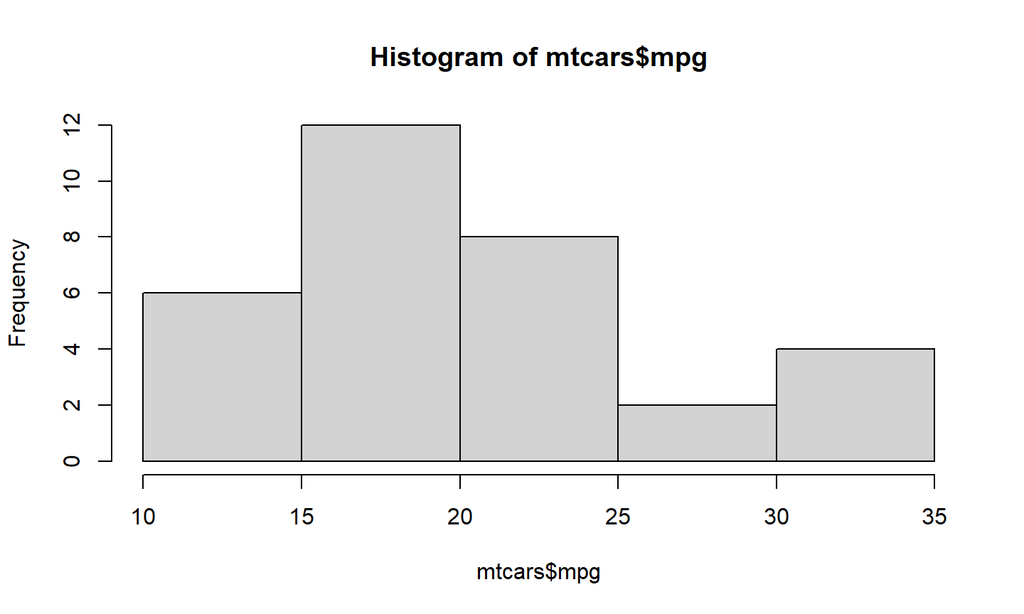

```r
data(mtcars)
hist(mtcars$mpg)
```

## Colored Histogram with Different Number of Bins

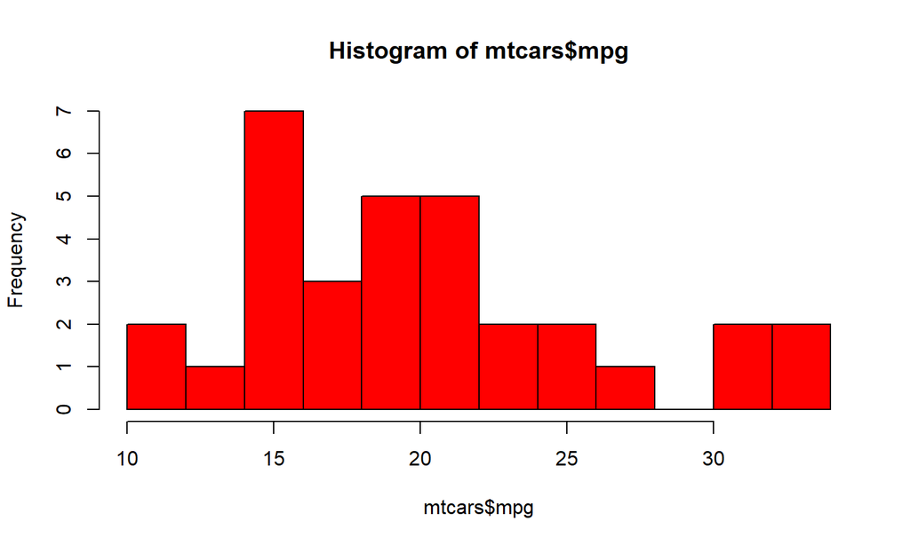

```r
hist(mtcars$mpg, breaks=12, col="red")
```

## Different h

```r
par(mfrow = c(2,2))
hist(mtcars$mpg, breaks=2, col="red")
hist(mtcars$mpg, breaks=8, col="red")
hist(mtcars$mpg, breaks=12, col="red")
hist(mtcars$mpg, breaks=20, col="red")
par(mfrow = c(1,1))
```

## Different h

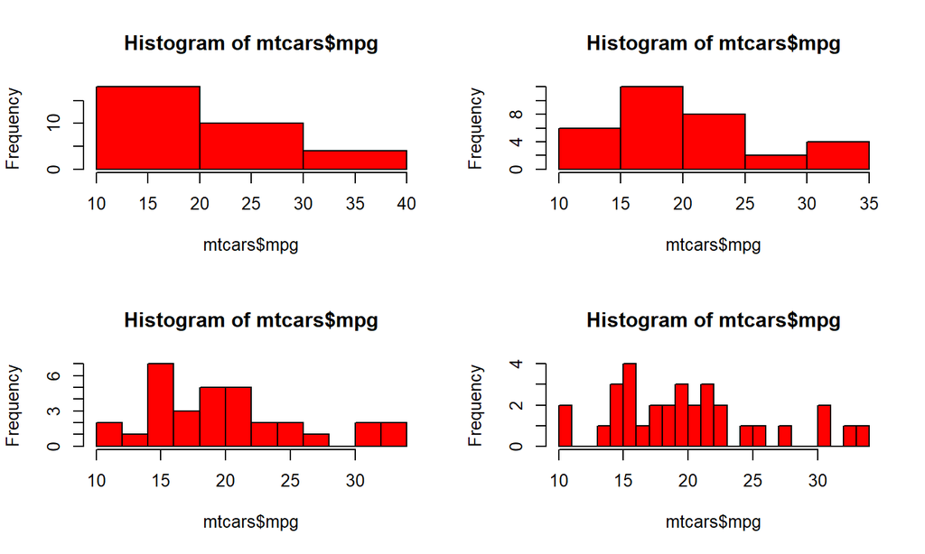

## Kernel Density Estimation

- Drawback of histogram: density estimation is piecewise constant and thus unsmooth.
- Main idea of kernel density estimation: instead of counting number of observations within \(h\) of \(x\), we take a certain weighted average of data points near \(x\) to estimate \(f(x)\).
- Usually we assign higher weights to data points closer to \(x\), and lower weights to those further away from \(x\).
- Kernel Density Estimate:

\[ \hat{f}(x) = \frac{1}{nh} \sum_{i=1}^{n} K\left(\frac{|{X_i - x|}}{h}\right). \] where \(K(\cdot)\) is a Kernel function.

- Choices: \(h\) bandwidth and \(K()\) the kernel.

## Choices of kernel function

- Uniform: \(K(u) = \frac{1}{2} I(|u| \le 1)\). Reduces to histogram.
- Gaussian: \(K(u) = \phi(u)\) (standard normal density).
- Triangle: \(K(u) = (1 - |u|) I(|u| \le 1)\).
- Epanechnikov: \(K(u) = \tfrac{3}{4}(1 - u^2) I(|u| \le 1)\).
- Biweight: \(K(u) = \tfrac{15}{16}(1 - u^2)^2 I(|u| \le 1)\).
- Triweight: \(K(u) = \tfrac{35}{32}(1 - u^2)^3 I(|u| \le 1)\).
- Minimum variance kernel (allowing negative weight):

\[ K(u) = \tfrac{1}{8}(3 - 5u^2) I(|u| \le 1). \]

## Choice of bandwidth \(h\)

A rule of thumb (Harfle, 1991): \[ h = \frac{1.06}{n^{1/5}} S, \] where \(S\) is the sample standard deviation, or a more robust version such as

- scaled interquartile range: \[ S = \frac{X_{(0.75)} - X_{(0.25)}}{1.34}, \]
- scaled MAD (median absolute deviation): \[ S = 1.4826 \cdot \text{Median}\{|X_i - \text{median}(X_i)|\}. \]

## Kernel function shapes

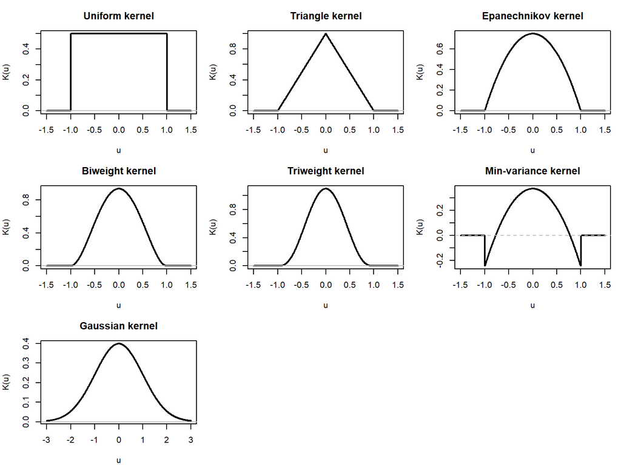

## Kernel Density Plot

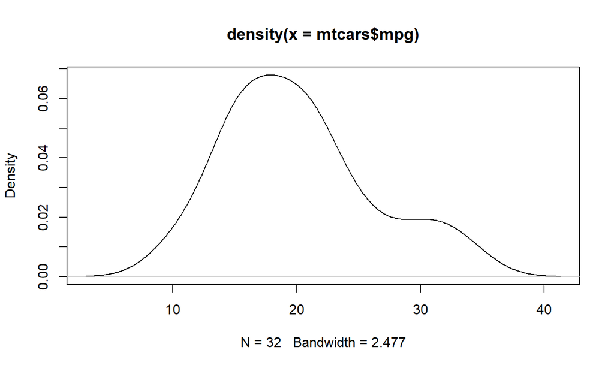

```r
d <- density(mtcars$mpg) # returns the density data
plot(d) # plots the results
```

## Kernel Density Plot with 1/3rd bandwith

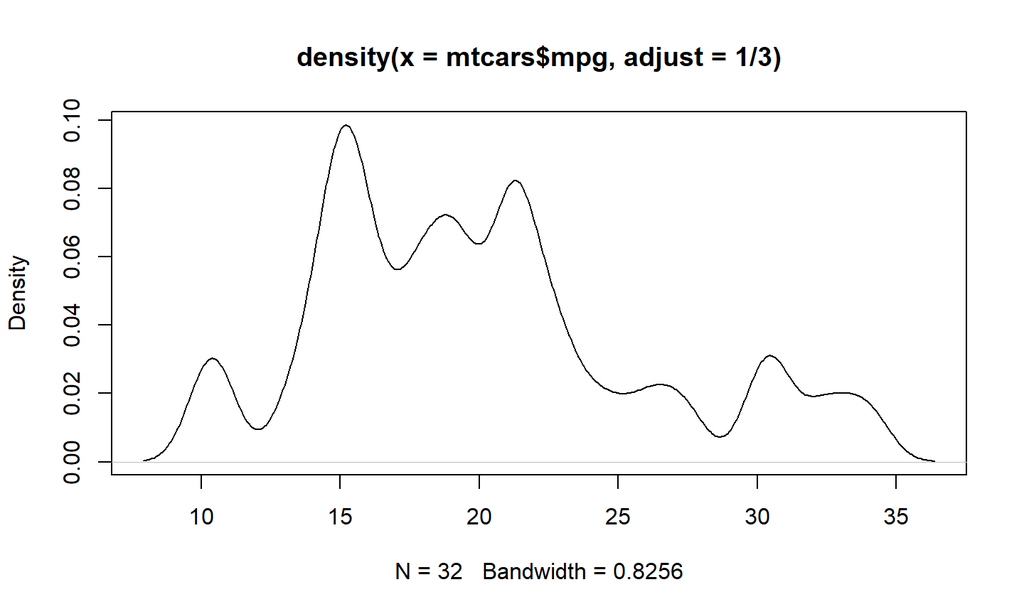

```r
d <- density(mtcars$mpg,adjust = 1/3) # returns the density data
plot(d) # plots the results
```

## Kernel Density Plot with 2x bandwith

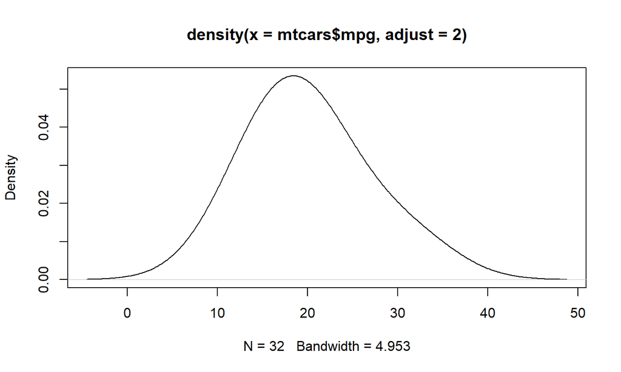

```r
d <- density(mtcars$mpg,adjust = 2) # returns the density data
plot(d) # plots the results
```

## Kernel Density Plot with a rectangular kernel

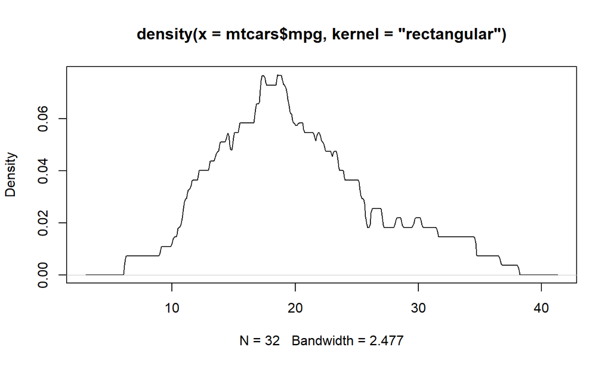

```r
d <- density(mtcars$mpg, kernel = "rectangular") # returns the density data
plot(d) # plots the results
```

## Kernel Density Plot with the Epanechnikov kernel

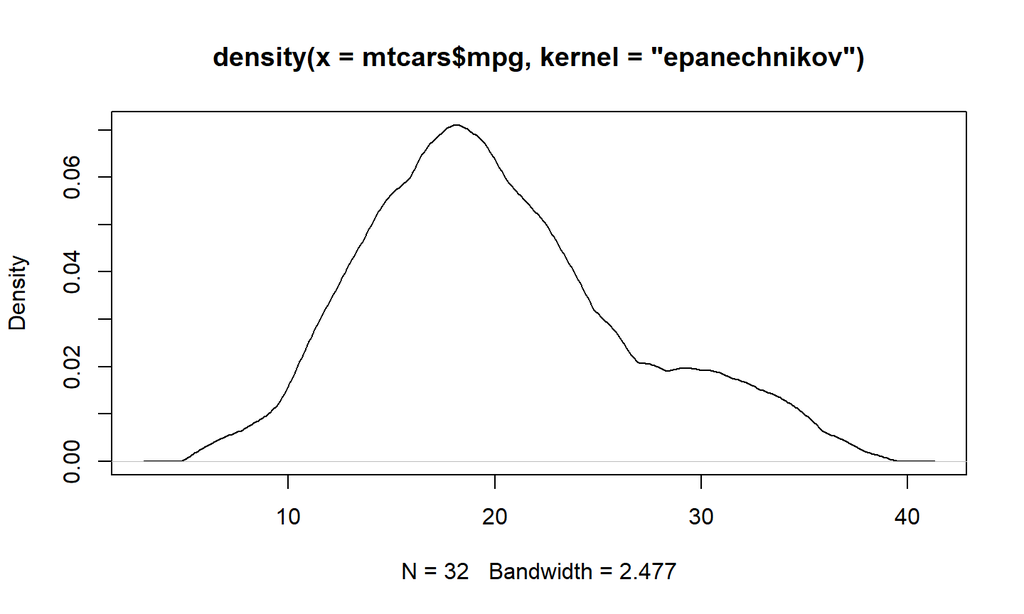

```r
d <- density(mtcars$mpg, kernel = "epanechnikov") # returns the density data
plot(d) # plots the results
```

## Faithful Geyser

```r
#take a look at the data set (the first 5 observations)
faithful[1:5,]
```

```
##   eruptions waiting
## 1     3.600      79
## 2     1.800      54
## 3     3.333      74
## 4     2.283      62
## 5     4.533      85
```

```r
duration = faithful$eruptions
n=length(duration)
#estimate the density using histogram and kernel estimation
```

## Different Kernels

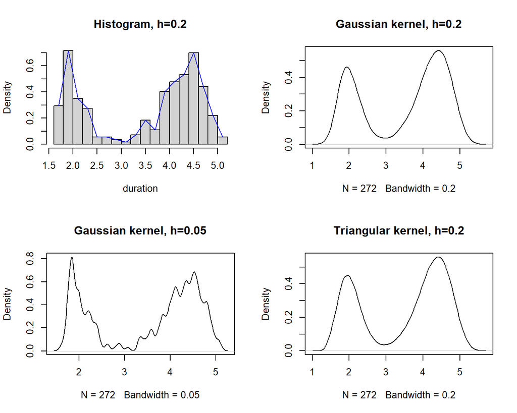

## We can also use ggplot

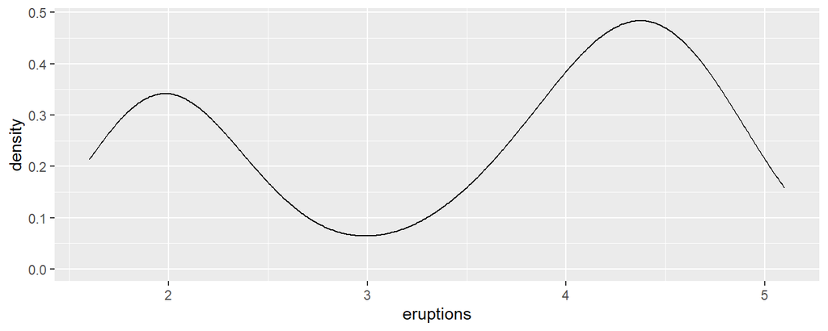

```r
library(ggplot2)
ggplot(data = faithful, aes(x = eruptions)) + geom_density()
```

## Different bandwidth

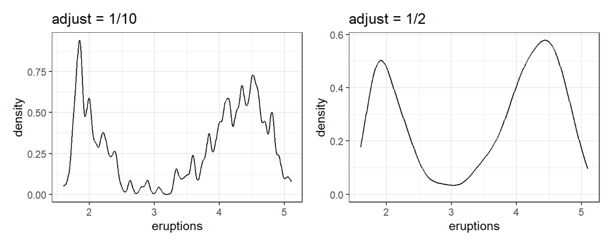

```r
library(patchwork)
p1 <- ggplot(data = faithful, aes(x = eruptions)) + geom_density(adjust = 1/10) +
  labs(title = "adjust = 1/10")+theme_bw()
p2 <- ggplot(data = faithful, aes(x = eruptions)) + geom_density(adjust = 1/2) +
  labs(title = "adjust = 1/2")+theme_bw()
p1+p2
```

## Different Kernels

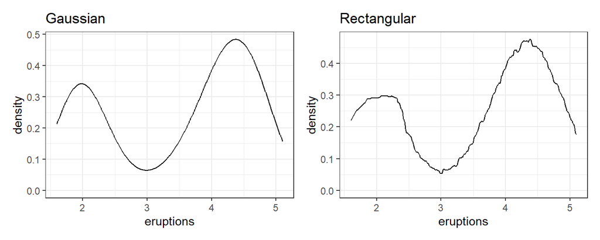

```r
p1 <- ggplot(data = faithful, aes(x = eruptions)) + geom_density(kernel = "gaussian") +
  labs(title = "Gaussian")+theme_bw()
p2 <- ggplot(data = faithful, aes(x = eruptions)) + geom_density(kernel = "rectangular") +
  labs(title = "Rectangular")+theme_bw()
p1+p2
```

## Drawing KDE manually

- We choose a range of values to plot using the minimum and maximum values of the data, and create a sequence of values using the seq() function. We set the bandwidth for the kernel density estimation using the bw variable.
- Next, we use the sapply() function to compute the kernel density estimate for each value in the sequence.

```r
# Generate some sample data
set.seed(123)
x <- rnorm(100)

# Choose a range of values to plot
xmin <- min(x)
xmax <- max(x)
xseq <- seq(xmin, xmax, length.out = 100)

# Set the bandwidth for the kernel density estimation
bw <- 0.5

# Compute the kernel density estimate
kde <- sapply(xseq, function(xi) {
  mean(dnorm((xi - x)/bw)/bw)
})
```

## Drawing KDE manually

- The R code on the last slide would produce this KDE.

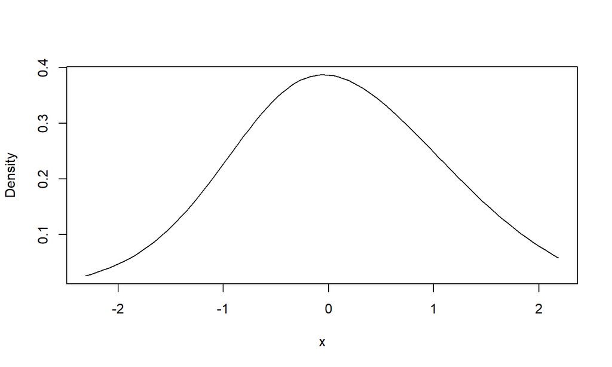